# Discrete Movement Models

[EFB 796: Techniques in Movement Ecology](https://eligurarie.github.io/MovementEcologyBook/EFB796/)

Elie Gurarie

October 2, 2025

> **Goal:** To understand and simulate discrete movement models including Random Walks, Autoregressive processes, Correlated Random Walks, and Multi-state Random Walks.

# Introduction

In this lab, we’ll explore different types of discrete movement models that are fundamental to understanding animal movement. We’ll start with simple random walks and build up to more complex multi-state models.

## Load packages

```r
library(circular)  # for circular statistics and wrapped Cauchy distribution
```

## Helper functions

The `scantrack` function will be helpful for visualizing movements in X and Y and against Time.

```r
# Function to visualize 2D tracks
scantrack <- function(Z, cex = 0.5, ...) {
  layout(rbind(c(1,2),c(1,3)))
  plot(Z, type = "o", pch = 19, cex = cex,
       xlab = "X", ylab = "Y", asp = 1, ...)
  points(c(Z[1], Z[length(Z)]), pch = 19, cex = 2,
           col = c("green", "red"))
  plot(1:length(Z), Re(Z), type = "o", pch = 19, cex = cex,
       xlab = "X", ylab = "Y", ...)
  plot(1:length(Z), Im(Z), type = "o", pch = 19, cex = cex,
       xlab = "X", ylab = "Y", ...)
}
```

# 1D White Noise

The simplest movement model is white noise - what we might call $WN(\sigma)$ - where each position is an independent draw from a normal distribution. We can notate that as:

$$\mathbf{X}_t \sim \sigma
W_t$$

Where $W_t$ is true “white noise”, i.e. uncorrelated, independent, identical realizations of a standard normal distribution:

$$W_t \sim {\cal N}(0,1)$$

Very simple to generate:

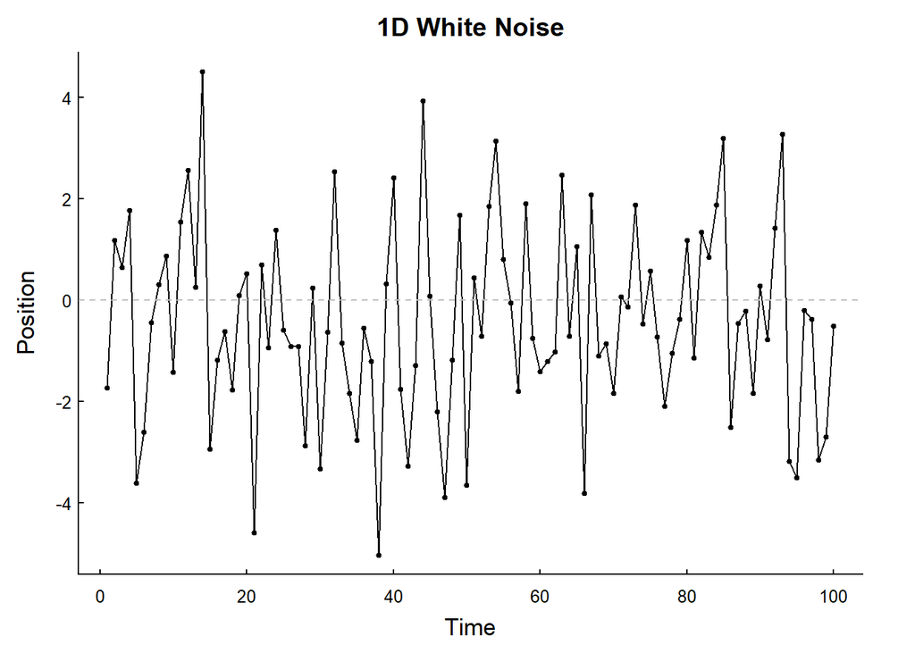

```r
# Parameters
sigma <- 2
n <- 100

# Simulate 1D white noise
X <- sigma * rnorm(n)

# Visualize
plot(1:length(X), X, type = "o", xlab = "Time", ylab = "Position",
     main = "1D White Noise", pch = 19, cex = 0.5)
abline(h = 0, lty = 2, col = "grey")
```

**Properties:**

- Expected position: $E(X_t) = 0$ (centered at origin)
- Variance: $\text{Var}(X_t) = \sigma^2$. In the context of *movement*, this means that it is spatially constrained (has a 1-D “home range”).
- No autocorrelation - each position is independent

Here’s one way to visualize many white noise processes:

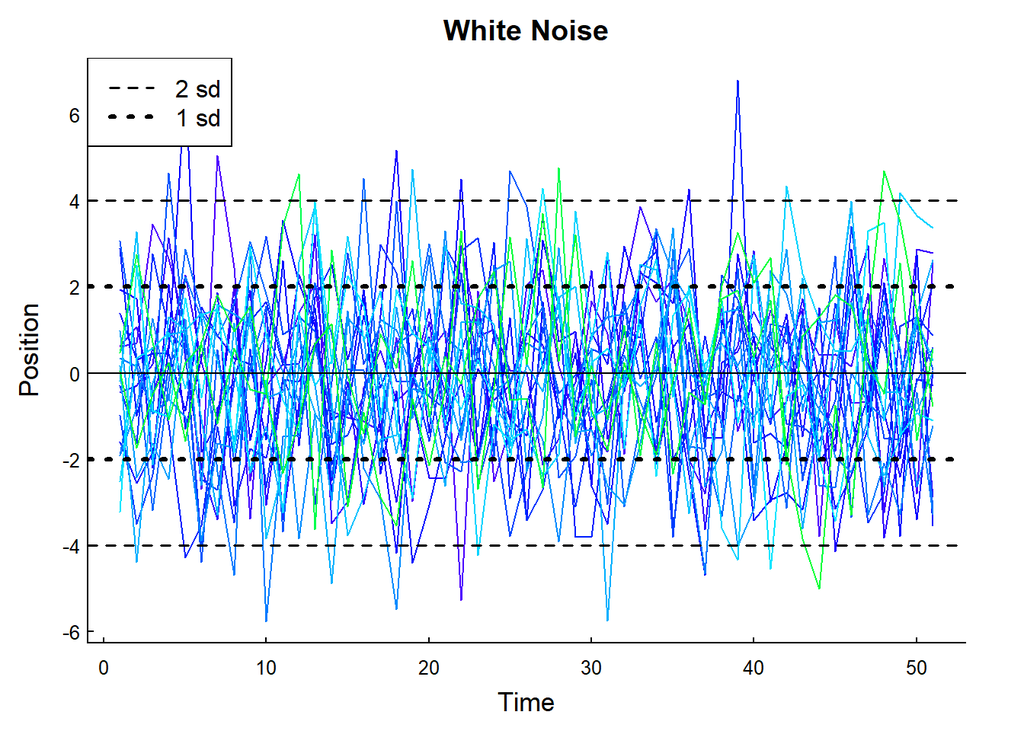

```r
i <- 1:20; n<- 50
X <- sapply(i, function(x) rnorm(n+1, sd = sigma))
matplot(X, type = "l", lty = 1, col = topo.colors(n), xlab = "Time",
        ylab = "Position", main = "White Noise")
abline(h = c(-2*sigma, -sigma, 0, sigma, 2*sigma), lty = c(2,3,1,3,2), col = "black", lwd = c(1.5,3,1,3,1.5))
legend("topleft", lwd = c(1.5,3), lty = c(2,3), legend = c("2 sd", "1 sd"))
```

# 2D White Noise

Extending this to 2 dimensions is as simple as making X and Y each be a WN($\sigma$) process. For convenience, we’ll use complex numbers, and the scantrack function to see how this process changes in time.

$$\mathbf{Z}_t \sim \mathcal{N}(0,
\sigma^2)$$

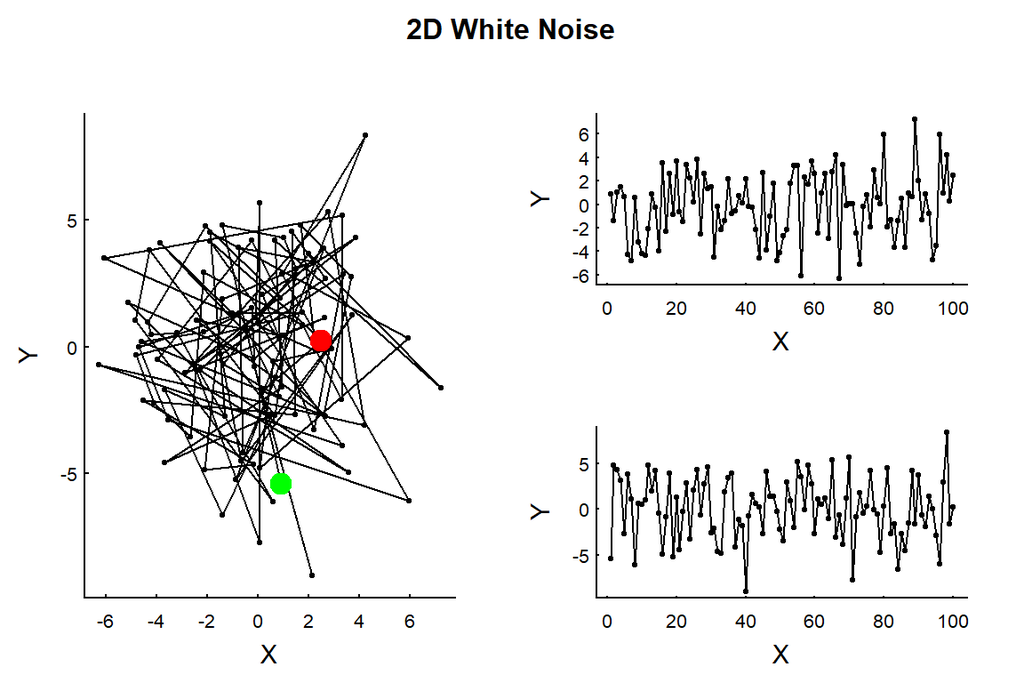

```r
# Parameters
sigma <- 3
n <- 100

# Simulate 2D white noise using complex numbers
Z <- rnorm(n, sd = sigma) + 1i * rnorm(n, sd = sigma)

# Visualize
scantrack(Z)
title("2D White Noise", outer = TRUE)
```

# 1D Random Walk

A random walk, in general, is a process where the location is a *cumulative sum* of a series of *steps*. The 1-dimensional **random walk**, where each *step* (not each *location*) is drawn from a normal distribution.
$$X_t = X_{t-1} + \sigma W_t$$

where $W_t \sim \mathcal{N}(0,1)$ is white noise and $\sigma$ controls step size.

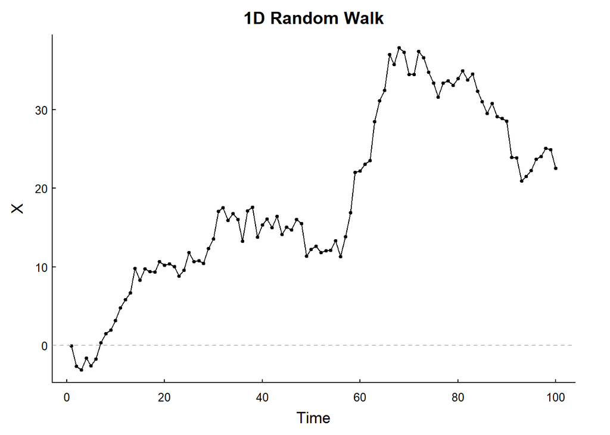

```r
# Parameters
sigma <- 2
n <- 100

# Simulate 1D random walk
X <- cumsum(rnorm(n, sd = sigma))

# Visualize
plot(1:length(X), X, type = "o", xlab = "Time",
     main = "1D Random Walk", pch = 19, cex = 0.5)
abline(h = 0, lty = 2, col = "grey")
```

**Properties:** - Expected position: $E(X_t) = 0$ (on average stays at origin) - Variance: $\text{Var}(X_t) = \sigma^2 t$ (variance increases with time) - Unconstrained - will wander to infinity!

Here’s one way to visualize all the random walks, and how the standard deviation increases as the square root of time:

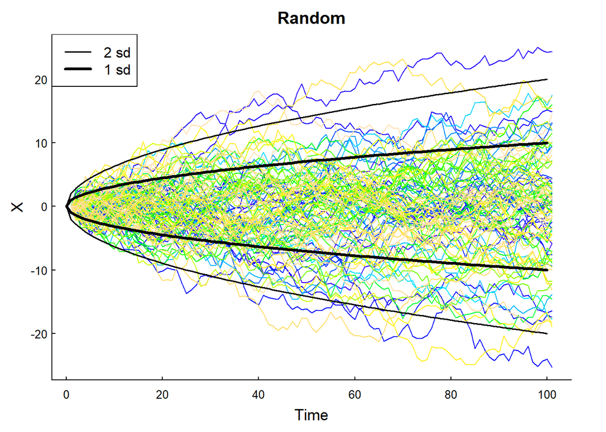

```r
i <- 1:100
X <- sapply(i, function(x) c(0,cumsum(rnorm(n))))
matplot(X, type = "l", lty = 1, col = topo.colors(100), xlab = "Time",
        main = "Random")
curve(2*sqrt(x), add = TRUE, lwd = 1.5, xlim = c(0,100))
curve(sqrt(x), add = TRUE, lwd = 3, xlim = c(0,100))
curve(-sqrt(x), add = TRUE, lwd = 3, xlim = c(0,100))
curve(-2*sqrt(x), add = TRUE, lwd = 1.5, xlim = c(0,100))
legend("topleft", lwd = c(1.5,3), legend = c("2 sd", "1 sd"))
```

# 2D Random Walk

We can extend this to 2 dimensions by creating independent random walks in X and Y. We’ll use complex numbers for convenient 2D representation.

$$\mathbf{Z}_t = \mathbf{Z}_{t-1} + \sigma
\mathbf{W}_t$$

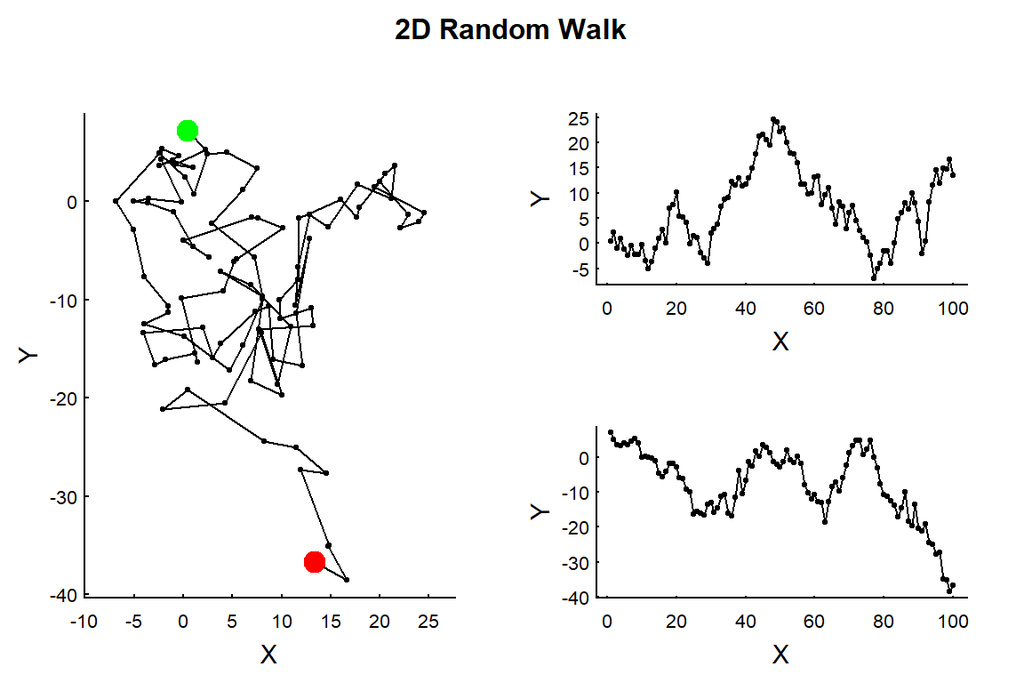

```r
# Parameters
sigma <- 3
n <- 100

# Simulate 2D random walk using complex numbers
Z <- cumsum(rnorm(n, sd = sigma)) + 1i * cumsum(rnorm(n, sd = sigma))

# Visualize
scantrack(Z)
title("2D Random Walk", outer = TRUE)
```

## Properties of 2D Random Walk

Let’s examine the step lengths and turning angles:

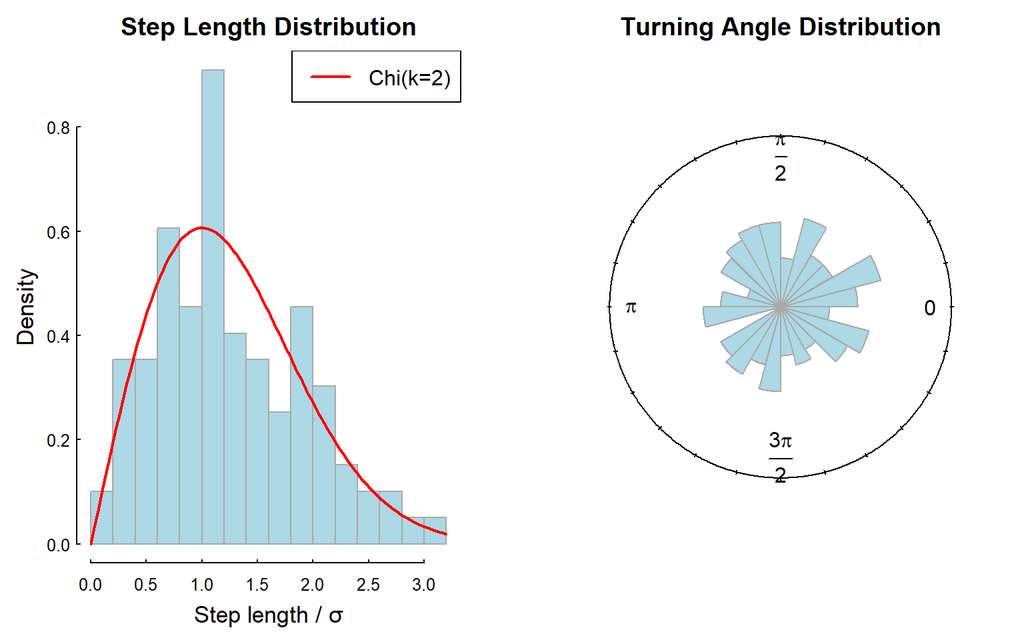

```r
# Calculate steps
S <- diff(Z)
step_lengths <- Mod(S)
turning_angles <- diff(Arg(S))

# Plot step length distribution
par(mfrow = c(1, 2))
hist(step_lengths / sigma, breaks = 20, freq = FALSE,
     main = "Step Length Distribution",
     xlab = "Step length / σ", col = "lightblue", border = "darkgrey")
curve(chi::dchi(x, df = 2), add = TRUE, col = "red", lwd = 2)
legend("topright", "Chi(k=2)", col = "red", lwd = 2)

# Plot turning angle distribution
rose.diag(turning_angles, bins = 24, prop = 2, col = "lightblue",
          border = "darkgrey", main = "Turning Angle Distribution")
```

# 1D Autoregressive Process (AR)

Unlike random walks that wander to infinity, autoregressive processes are spatially constrained.

$$X_t = \phi X_{t-1} + \sigma
W_t$$

where $\phi$ is the autocorrelation parameter (0 < $\phi$ < 1).

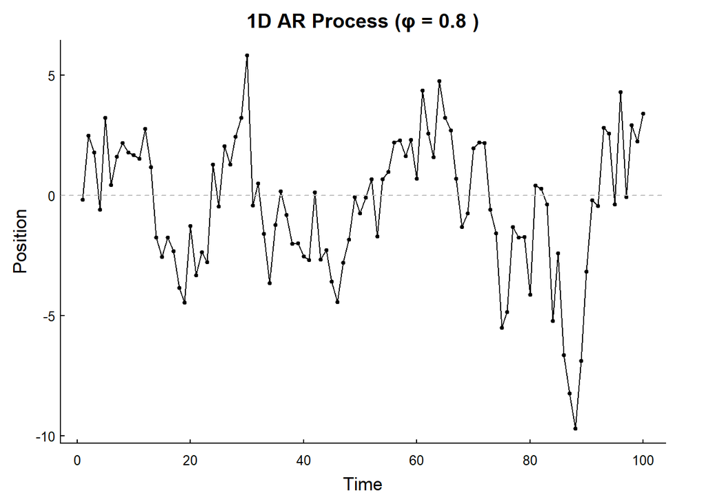

```r
# Function to simulate 1D AR process
AR1D <- function(n = 100, sigma = 2, phi = 0.8, mu = 0) {
  X <- numeric(n)
  X[1] <- rnorm(1, 0, sigma)
  for(i in 2:n) {
    X[i] <- phi * X[i-1] + rnorm(1, 0, sigma)
  }
  X + mu
}

# Simulate
sigma <- 2
phi <- 0.8
n <- 100
X <- AR1D(n, sigma, phi)

# Visualize
pars()
plot(1:length(X), X, type = "o", xlab = "Time", ylab = "Position",
     main = paste("1D AR Process (φ =", phi, ")"), pch = 19, cex = 0.5)
abline(h = 0, lty = 2, col = "grey")
```

**Properties:** - Expected position: $E(X_t) = 0$ (or $\mu$ if shifted) - Variance: $\text{Var}(X_t) = \frac{\sigma^2}{1-\phi^2}$ (spatially constrained!) - The autocorrelation parameter $\phi$ controls how strongly positions are correlated

Let’s examine the autocorrelation:

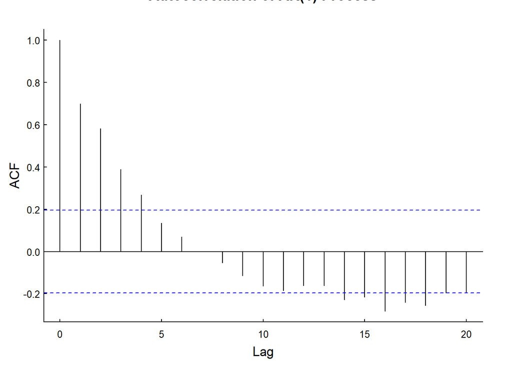

```r
acf(X, main = "Autocorrelation of AR(1) Process")
```

Notice the exponential decay in the autocorrelation function - this is characteristic of AR processes.

# 2D Autoregressive Walk

We can extend the AR process to 2D by having independent AR processes in X and Y dimensions.

$$\mathbf{Z}_t = \phi \mathbf{Z}_{t-1} +
\sigma \mathbf{W}_t$$

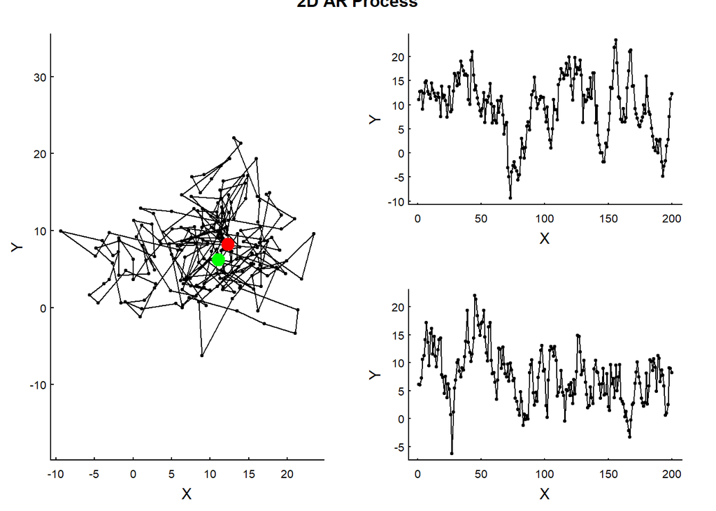

```r
# Function to simulate 2D AR process
AR2D <- function(n = 100, phi = 0.8, sigma = 1, mu = 0) {
  X <- AR1D(n, sigma, phi, Re(mu))
  Y <- AR1D(n, sigma, phi, Im(mu))
  X + 1i * Y
}

# Simulate
Z <- AR2D(n = 200, phi = 0.8, sigma = 3, mu = 10 + 1i*5)

# Visualize
scantrack(Z)
title("2D AR Process", outer = TRUE)
```

This looks like home-ranging behavior! The animal stays within a bounded area.

## Home range approximation

For a 2D AR process, the 95% home range area can be approximated as:

$$A \approx
\frac{6\pi\sigma^2}{1-\phi^2}$$

where 6 ≈ -2 log(0.05).

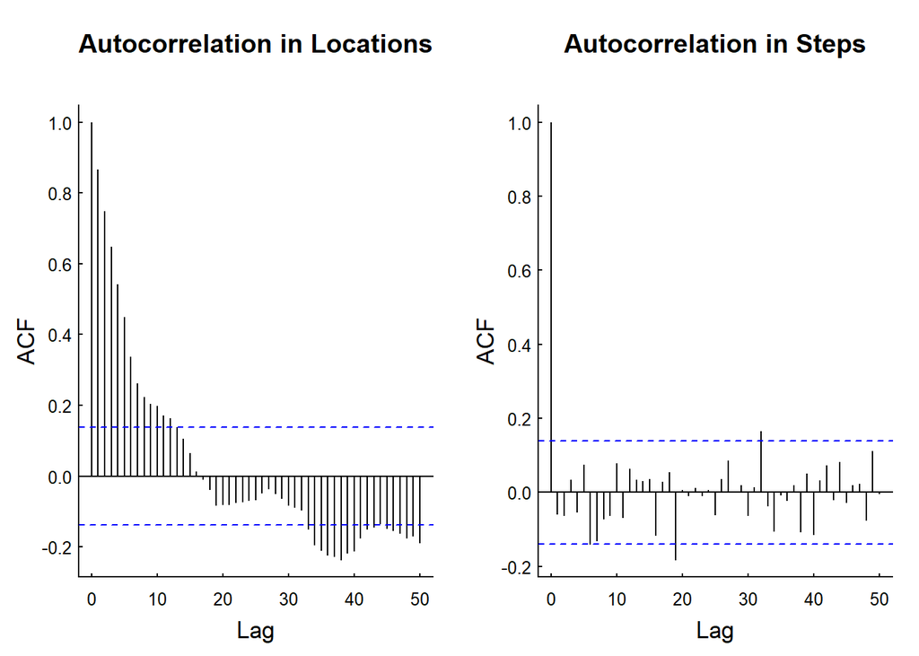

```r
# Calculate theoretical home range
sigma <- 3
phi <- 0.8

# The AR process has autocorrelation in locations...
acf(Re(Z), main = "Autocorrelation in Locations", lag.max = 50)

# ...but NOT in the steps
acf(Re(diff(Z)), main = "Autocorrelation in Steps", lag.max = 50)
```